# Spotify listening history analysis

In this article, I'll look into some data I've been pulling from Spotify's API over the past few months. The data is stored as a comma separated file in a FileShare through my Microsoft Azure account. That account also has a Function App currently being called from a Timer Trigger, which sends a request every 3 hours for the last 50 songs played through my Spotify account. (Only new data points are added to the csv.)

The goal of this analysis will be to observe my listening habits, i.e. tops artists and songs, music per time of day, even track meta-data and feature analysis (using the `audio-features` and `audio-analysis` calls to Spotify's API). At the end, I'll run a final analysis, where a simple machine learning model will be fit on the data to predict which time of day a specific song may be listened to.

# Preparing the data

We'll start by downloading our csv, and converting it to a pandas data frame. Connecting to my Azure Storage Account requires a connection string, which I have stored as an environment variable on my local machine (called `SPOTIFYHISTORY_CONN_STR`).

```python
# download module to access files in an Azure FileShare
# pip install azure-storage-file-share
```

```python
from azure.storage.fileshare import ShareFileClient
import io, os
import pandas as pd
import matplotlib.pyplot as plt
from tqdm import tqdm
from datetime import datetime, timedelta
import warnings
warnings.filterwarnings('ignore')
%matplotlib inline
%load_ext autoreload
%autoreload 2
```

```
The autoreload extension is already loaded. To reload it, use:
  %reload_ext autoreload
```

```python
# connecting to FileShare
conn_str = os.environ.get('SPOTIFYHISTORY_CONN_STR')
file_client = ShareFileClient.from_connection_string(conn_str=conn_str, share_name='history',file_path='history.csv')

# downloading csv
stream_download = file_client.download_file()
csv_text = stream_download.content_as_text()

# convert csv to dataframe
string_stream = io.StringIO(csv_text) # bc \n line seperators
history = pd.read_csv(string_stream)
entries = history.shape[0]
print(entries)
```

```
7573
```

Great, there are currently 7573 entries.

```python
history.tail()
```

|  | played_at | id | artist | name |
| --- | --- | --- | --- | --- |
| 7568 | 2020-12-09T19:09:26.869Z | 1JZW4KLFdvnpUfw3zSvsIl | MF DOOM | Coco Mango (FloFilz Remix) |
| 7569 | 2020-12-09T19:11:52.521Z | 5oRqxClXoZB77vvENaqDAB | FloFilz | Hoxton Hoops |
| 7570 | 2020-12-09T19:14:10.746Z | 1uju5gePcrpwmrg4F0kS7A | FloFilz | Cabaceira |
| 7571 | 2020-12-09T19:16:37.971Z | 5F0WNf41jS3q3LnwrFIjsm | Simon Jefferis | Bella notte |
| 7572 | 2020-12-09T19:18:49.786Z | 3KPhaCvEPAKmwgYd8LARFe | Demuja | Do You Want My Love |

# Top artists and songs

Let's create a quick bar chart of the top 25 artist in this data-set, i.e. those artists which occur the *most often*.

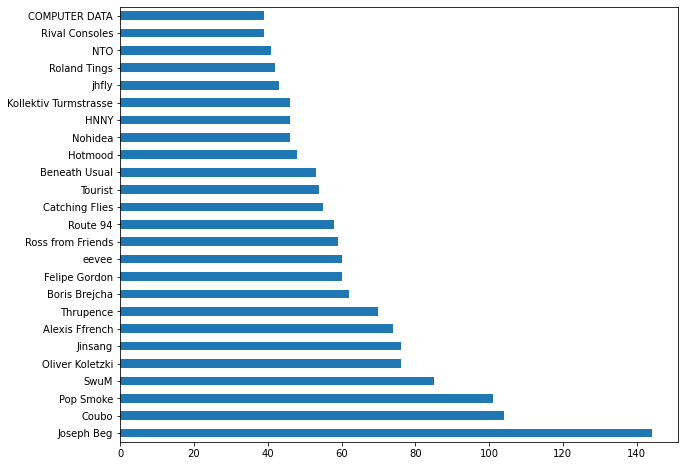

```python
plt.figure(figsize=(10,8))
top_artists = history['artist'].value_counts()
top_artists[:25].plot.barh()
```

Cool, now we can do the same for the top 25 songs. In our data frame, the song titles are found in the `names`column.

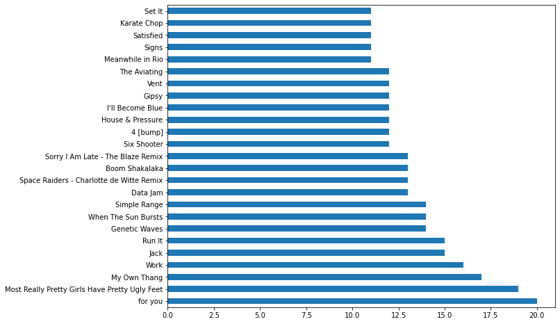

```python
plt.figure(figsize=(10,8))
top_songs = history['name'].value_counts()
top_songs[:25].plot.barh()
```

Let's make a function that does this for us, so we don't have to keep writing this.

```python
def top(n=25, df=history, show=False):
    artists = df['artist'].value_counts()
    songs = df['name'].value_counts()

    if show:
        plt.figure(figsize=(10,int(n/2)))
        artists[:n].plot.barh()
        plt.xlabel('Number of plays')
        plt.title(f'Top {n} artists')
        plt.show()

        plt.figure(figsize=(10,int(n/2)))
        songs[:n].plot.barh()
        plt.xlabel('Number of plays')
        plt.title(f'Top {n} songs')
        plt.show()
    return artists[:n],  songs[:n]
```

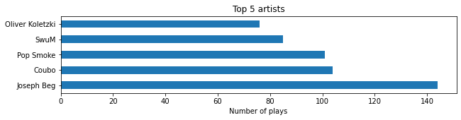

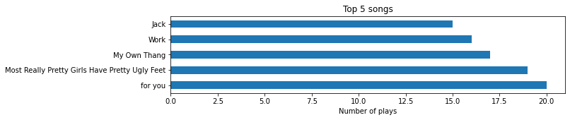

```
Joseph Beg         144
Coubo              104
Pop Smoke          101
SwuM                85
Oliver Koletzki     76
Name: artist, dtype: int64
```

```python
top(5, show=True)[0]
```

# Past months

We now want to change the window of our observations. Instead of taking in the entire dataset, let's look at those entries only from the last `n` month(s). I'll go ahead and write this as a function.

```python
def past_months(number_of_months=1):
    then_dt = datetime.now().replace(month=datetime.now().month - number_of_months)
    then = then_dt.strftime('%Y-%m-%dT%H:%M:%S.%f')[:-3]+'Z'
    return history[history['played_at']>then]
```

```python
past_month = past_months(1)
past_month.head(30)
```

|  | played_at | id | artist | name |
| --- | --- | --- | --- | --- |
| 7406 | 2020-12-07T14:02:26.940Z | 6kTteVJEEkVs3Zges11EPO | Leon Vynehall | I Cavallo |
| 7407 | 2020-12-07T14:06:10.753Z | 1OD2YXIOmfYmBAYfV1maRV | Leon Vynehall | Movements (Chapter III) |
| 7408 | 2020-12-07T14:27:16.710Z | 53jeGIP3iM5S1wYILdgVmq | Leon Vynehall | Midnight on Rainbow Road |
| 7409 | 2020-12-07T14:35:39.807Z | 19uZpCvv7D2xcz2KwXFgiO | Leon Vynehall | Blush |
| 7410 | 2020-12-07T14:40:11.200Z | 3q5wn2zu1Bt5NOxmwfGtCn | Michael Christmas | Not the Only One |
| 7411 | 2020-12-07T14:46:44.840Z | 3qAvjZ84KUD5cCWkt4iCcb | Kornél Kovács | Szikra |
| 7412 | 2020-12-07T14:52:58.667Z | 13T8SvWHczyBPzOemKtEe7 | Subjoi | Love Shy - Subjoi's Tuff Jam Rework |
| 7413 | 2020-12-07T15:01:21.852Z | 3ilkEyg6OCtd9qCnOJkPzU | DJ BORING | Winona |
| 7414 | 2020-12-07T15:07:08.281Z | 4sWJCVOn705QUBCDt81bPB | Baltra | O'Neal |
| 7415 | 2020-12-07T15:13:10.796Z | 239SrBPZi0xs1OQZmedr6q | Oliver Koletzki | A Tribe Called Kotori |
| 7416 | 2020-12-07T15:17:57.481Z | 0n1KK4wHT71v40NBhOCbfz | Tourist | Last |
| 7417 | 2020-12-07T15:24:38.238Z | 2xLEReg75mzKpqyRs4DDKu | Mall Grab | I've Always Liked Grime |
| 7418 | 2020-12-07T15:31:28.003Z | 3ZZwblSjDYLSgHDIV3EApr | Baltra | Fade Away (Vocal) |
| 7419 | 2020-12-07T15:38:12.960Z | 6dp0QJLplcEvH8DIUVzNgR | Justice Der | L$D |
| 7420 | 2020-12-07T15:40:22.400Z | 1uju5gePcrpwmrg4F0kS7A | FloFilz | Cabaceira |
| 7421 | 2020-12-07T15:43:57.681Z | 27ycaQnQAxaPiyeg3nr2aB | Miley Cyrus | Midnight Sky |
| 7422 | 2020-12-07T15:55:42.686Z | 2LseyBkPJv7r7wCt2yMEgX | Miley Cyrus | High |
| 7423 | 2020-12-07T15:59:15.319Z | 1Tip6R4swhC7E6hgILBjrE | Miley Cyrus | Edge of Midnight (Midnight Sky Remix) (feat. S... |
| 7424 | 2020-12-07T16:02:20.132Z | 37PJvlIfYWqEX6fgjHlnTf | Miley Cyrus | WTF Do I Know |
| 7425 | 2020-12-07T16:05:54.408Z | 4U34WsyOvppOMnRfq7DuOy | Miley Cyrus | Night Crawling (feat. Billy Idol) |
| 7426 | 2020-12-07T16:09:42.152Z | 68qkDbsvprJRG5xw2R02dy | Miley Cyrus | Golden G String |
| 7427 | 2020-12-07T16:15:14.412Z | 6qCsKKS7Ol63SJW3LOIX5R | Miley Cyrus | Plastic Hearts |
| 7428 | 2020-12-07T16:18:30.860Z | 1daDRI9ahBonbWD8YcxOIB | Miley Cyrus | Angels Like You |
| 7429 | 2020-12-07T16:21:20.171Z | 2Oycxb8QbPkpHTo8ZrmG0B | Miley Cyrus | Prisoner (feat. Dua Lipa) |
| 7430 | 2020-12-07T16:23:51.909Z | 4v8jmsVox8VwU5js3JHOJZ | Miley Cyrus | Gimme What I Want |
| 7431 | 2020-12-07T16:27:00.787Z | 4U34WsyOvppOMnRfq7DuOy | Miley Cyrus | Night Crawling (feat. Billy Idol) |
| 7432 | 2020-12-07T16:30:44.170Z | 4i2qxFEVVUi8yOYoxB8TCX | Miley Cyrus | Midnight Sky |
| 7433 | 2020-12-07T16:34:00.787Z | 2LseyBkPJv7r7wCt2yMEgX | Miley Cyrus | High |
| 7434 | 2020-12-07T16:36:38.668Z | 0rFcav2bUNH6NC9576Viiu | Miley Cyrus | Hate Me |
| 7435 | 2020-12-07T16:39:46.780Z | 47KegqqrzpKw0jdHFWqtNb | Miley Cyrus | Bad Karma (feat. Joan Jett) |

We can now combine our two functions, for an elegant way of printing the top artists and song names for the past `n` months.

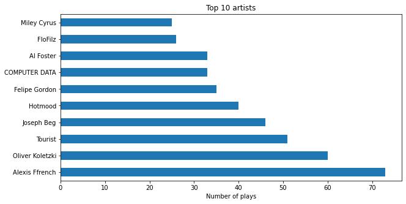

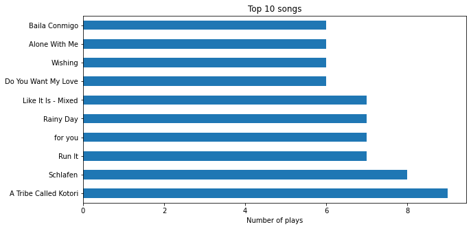

```python
top(10, past_months(3), show=True)
None
```

# Times of day

We can now start looking more into the specific times of day different listening habits occurred. Here, I'll add the timezone to the the stored songs using `tz_convert()`, although this is not entirely necessary for this analysis.

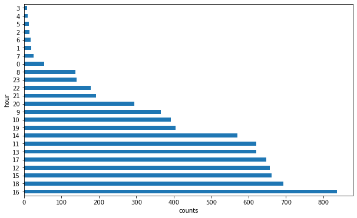

```python
played_at = pd.to_datetime(history['played_at']).dt.tz_convert('Europe/Oslo')
hours = played_at.dt.hour
plt.figure(figsize=(10, 6))
hours.value_counts().plot.barh()
plt.xlabel('counts')
plt.ylabel('hour')
None
```

Here, it could be interesting to see how many different days had registered music, to normalize these entries.

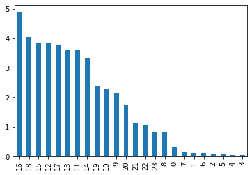

```python
unique_days = pd.unique(played_at.dt.date)
num_days = len(unique_days)
avg_hours = hours.value_counts()/num_days   # add tail(12) here to show the markdown variables
avg_hours.plot.bar()
```

So on average, in my most popular listening hour, I listened to roughly 5 songs from 16:00 to 17:00.

We can also see my least popular listening hours [7, 1, 6, 2, 5, 4, 3].

# Meta-data and Features

In order to start analyzing the type of music per day time, we'll need to make some calls to the open Spotify API. Here, I'll read in my client id and secret, again from my environment variables.

```python
import requests as r
import base64

def get_spotify_header():
    # connection string and secret from env. var.
    client_id = os.getenv('SPOTIFY_CLIENT_ID')
    client_secret = os.getenv('SPOTIFY_CLIENT_SECRET')

    # build header info from env. var.
    clientb = base64.b64encode(f'{client_id}:{client_secret}'.encode('utf-8'))
    client = str(clientb, 'utf-8')
    header = {'Authorization': f'Basic {client}'}
    token = r.post('https://accounts.spotify.com/api/token', headers=header, data={'grant_type':'client_credentials'}).json()
    header['Authorization'] = 'Bearer ' +token['access_token']
    return header

header = get_spotify_header()
```

It's important to note that this header is only valid for an hour at a time. It can be refreshed by just calling on `get_spotify_header()` again.

There are two endpoints we can call here for more details about our songs. `audio-features` gives a reduced list of interesting metrics of a track, including danceability, energy, loudness, and tempo. `audio-analysis` gives more practical information about the song's structure, including large codes-strings for metrics like rhythm and tune. We can define functions for these calls for easy use later.

```python
def get_features(track_id=history['id'][0], update_header=False, header=header):
    if update_header:
        header=get_spotify_header() # to make sure this is always updated
    features = r.get(f'https://api.spotify.com/v1/audio-features/{track_id}', headers=header)
    return features.json()

get_features()
```

```
{'danceability': 0.663,
 'energy': 0.582,
 'key': 10,
 'loudness': -8.426,
 'mode': 0,
 'speechiness': 0.043,
 'acousticness': 0.0879,
 'instrumentalness': 0.838,
 'liveness': 0.301,
 'valence': 0.0984,
 'tempo': 135.32,
 'type': 'audio_features',
 'id': '6r647IcY3VbHY7zEmtAAdS',
 'uri': 'spotify:track:6r647IcY3VbHY7zEmtAAdS',
 'track_href': 'https://api.spotify.com/v1/tracks/6r647IcY3VbHY7zEmtAAdS',
 'analysis_url': 'https://api.spotify.com/v1/audio-analysis/6r647IcY3VbHY7zEmtAAdS',
 'duration_ms': 240627,
 'time_signature': 4}
```

```python
history.iloc[0]
```

```
played_at    2020-03-19T14:59:51.544Z
id             6r647IcY3VbHY7zEmtAAdS
artist                        Ratatat
name                       Bob Gandhi
Name: 0, dtype: object
```

```python
def get_analysis(track_id = history['id'][0], update_header=False, header=header):
    if update_header:
        header=get_spotify_header() # to make sure this is always updated
    audio_analysis = r.get(f'https://api.spotify.com/v1/audio-analysis/{track_id}', headers=header)
    return audio_analysis.json()['track']

get_analysis()
```

[output not shown]

The code strings code be very interesting to study as it is probably a string representation of the audio file that builds the song. (I wonder if it's possible to recreate an audio file form this string...?) This could be good for some deep learning project, but for now let's just focus on the features. We'll also select a subset of our data for a simplified analysis.

```python
past_3_months = past_months(3)
top_artists, top_songs = top(50, past_3_months)
top_songs.head()
```

```
A Tribe Called Kotori    9
Schlafen                 8
Run It                   7
for you                  7
Rainy Day                7
Name: name, dtype: int64
```

```python
selected_features = ['danceability', 'energy',
                     'instrumentalness', 'tempo', 'duration_ms']
```

Now we have the top 50 artists and the top 50 songs for the past 3 months. Let's select a few features available from the API call we executed above. Specifically, I'll look at ['danceability', 'energy', 'instrumentalness', 'tempo', 'duration_ms'].

Since the API will always return the same list of columns, I'll just make a data frame using all the items from the returned json package.

```python
features = pd.DataFrame(columns=get_features().keys())
```

```python
for song in tqdm(top_songs.index):
    track_id = past_3_months[past_3_months['name'] == song]['id'].values[0]
    features.loc[song] = get_features(track_id)
```

```python
features[selected_features]
```

|  | danceability | energy | instrumentalness | tempo | duration_ms |
| --- | --- | --- | --- | --- | --- |
| A Tribe Called Kotori | 0.627 | 0.4960 | 0.83100 | 95.000 | 370453 |
| Schlafen | 0.778 | 0.5030 | 0.90000 | 128.014 | 412500 |
| Run It | 0.797 | 0.8580 | 0.88200 | 124.999 | 206261 |
| for you | 0.637 | 0.4930 | 0.05760 | 125.949 | 188611 |
| Rainy Day | 0.204 | 0.0578 | 0.95600 | 79.812 | 186000 |
| Like It Is - Mixed | 0.881 | 0.7970 | 0.16700 | 123.003 | 262924 |
| Do You Want My Love | 0.871 | 0.5920 | 0.68700 | 123.999 | 321733 |
| Wishing | 0.501 | 0.1230 | 0.93000 | 73.463 | 128907 |
| Alone With Me | 0.713 | 0.5780 | 0.91500 | 116.992 | 453971 |
| Baila Conmigo | 0.878 | 0.9260 | 0.30200 | 121.996 | 377344 |
| For Now Onwards | 0.780 | 0.8060 | 0.89200 | 123.507 | 313382 |
| Spiritual but Not Religious | 0.671 | 0.4970 | 0.53600 | 95.005 | 246707 |
| Te Voy a Encontrar | 0.742 | 0.8900 | 0.13100 | 120.012 | 340480 |
| I'll Become Blue | 0.661 | 0.6720 | 0.06000 | 120.001 | 337377 |
| Satisfied | 0.689 | 0.5120 | 0.32600 | 122.032 | 317178 |
| Gotta Keep Us Separated | 0.735 | 0.7390 | 0.78400 | 122.991 | 359560 |
| Most Really Pretty Girls Have Pretty Ugly Feet | 0.929 | 0.4490 | 0.49000 | 119.896 | 285440 |
| Gettin' It Done | 0.843 | 0.7040 | 0.76300 | 126.987 | 306685 |
| The Way Back | 0.855 | 0.4250 | 0.85200 | 120.025 | 446053 |
| Poseidon | 0.728 | 0.8350 | 0.86100 | 126.996 | 266467 |
| Don't Brake It | 0.759 | 0.7020 | 0.70200 | 118.017 | 395604 |
| Work | 0.821 | 0.8220 | 0.84300 | 124.019 | 332903 |
| Nova | 0.746 | 0.3940 | 0.91400 | 123.001 | 442525 |
| Yamaha | 0.789 | 0.5020 | 0.91700 | 121.020 | 388484 |
| Planetarium | 0.804 | 0.5880 | 0.85400 | 125.997 | 413560 |
| Someone Else | 0.340 | 0.4390 | 0.95400 | 132.004 | 247266 |
| We Got The Power | 0.796 | 0.7500 | 0.81100 | 120.024 | 352000 |
| Fly Kicks - Wax Motif Remix | 0.897 | 0.6920 | 0.72800 | 125.024 | 278400 |
| The Day We Leave Earth | 0.342 | 0.1440 | 0.83200 | 100.000 | 415493 |
| Sorry I Am Late - The Blaze Remix | 0.827 | 0.5400 | 0.71900 | 122.024 | 323218 |
| Saw You for the First Time | 0.805 | 0.5290 | 0.89400 | 121.004 | 404630 |
| Our Son | 0.482 | 0.1010 | 0.00335 | 105.719 | 162280 |
| For A Bright & Acid Future | 0.803 | 0.7570 | 0.66100 | 123.016 | 455000 |
| Tankwa Town | 0.736 | 0.4010 | 0.29300 | 100.008 | 453507 |
| Earth Tones - Felipe Gordon Remix | 0.801 | 0.7430 | 0.91600 | 126.526 | 457757 |
| Affection | 0.217 | 0.2660 | 0.91300 | 119.178 | 195948 |
| Apollo | 0.661 | 0.5340 | 0.87700 | 120.007 | 392490 |
| Control | 0.860 | 0.3630 | 0.00109 | 120.033 | 170005 |
| When The Sun Bursts | 0.610 | 0.7270 | 0.44000 | 119.031 | 259528 |
| Jack | 0.829 | 0.8830 | 0.76200 | 123.969 | 220665 |
| Moments | 0.121 | 0.0485 | 0.94500 | 80.794 | 204706 |
| 6 AM Mimosa | 0.803 | 0.6960 | 0.92900 | 123.998 | 506770 |
| Emily | 0.541 | 0.6730 | 0.14800 | 108.980 | 231804 |
| Moonlight | 0.813 | 0.7610 | 0.01190 | 124.957 | 173067 |
| My Bright Red Juicy Lips | 0.859 | 0.6670 | 0.15900 | 118.015 | 364735 |
| Swimmer | 0.547 | 0.9410 | 0.85000 | 178.016 | 524821 |
| Habibi Dub - Mix & Fairbanks Remix | 0.802 | 0.9090 | 0.53300 | 122.000 | 378828 |
| In Time | 0.777 | 0.7400 | 0.70500 | 126.026 | 259165 |
| Space Raiders - Charlotte de Witte Remix | 0.749 | 0.7310 | 0.86700 | 131.997 | 438720 |
| intro | 0.807 | 0.4940 | 0.08930 | 78.005 | 152404 |

Now we're starting to see some real data on this music history. Let's take a look at the distributions of these features.

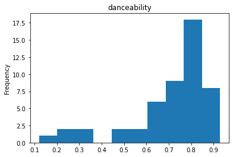

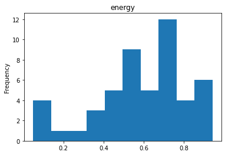

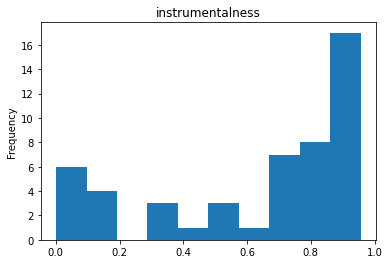

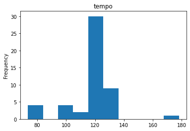

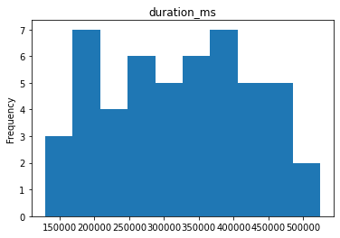

```python
for f in selected_features:
    features[f].plot.hist(bins=10)
    plt.title(f)
    plt.show()
```

These plots show the distributions of our selected features for the top 50 songs we chose.

To get these data, I used my home-made function `get_features()` which calls the API for each song in our tops songs through a for loop. The Spotify API however has an endpoint for feature requests for a list of track ids as well. This can limit the amount of calls we have to make the the API, and speed up our overall computation time.

```python
def format_ids(ids_list):
    ids_str = ''
    for f in ids_list:
        ids_str += f+','
    return ids_str[:-1]

# convert ids to format for api
ids = format_ids(features.id.values)

# api request
big_features_request = r.get(f'https://api.spotify.com/v1/audio-features/?ids={ids}',
                     headers=header)
# convert to df
big_features = pd.DataFrame.from_dict(big_features_request.json()['audio_features'])

# song names as index
big_features.index = top_songs.index
big_features
```

|  | danceability | energy | key | loudness | mode | speechiness | acousticness | instrumentalness | liveness | valence | tempo | type | id | uri | track_href | analysis_url | duration_ms | time_signature |
| --- | --- | --- | --- | --- | --- | --- | --- | --- | --- | --- | --- | --- | --- | --- | --- | --- | --- | --- |
| A Tribe Called Kotori | 0.627 | 0.4960 | 5 | -11.866 | 0 | 0.0396 | 0.710000 | 0.83100 | 0.3430 | 0.0801 | 95.000 | audio_features | 239SrBPZi0xs1OQZmedr6q | spotify:track:239SrBPZi0xs1OQZmedr6q | https://api.spotify.com/v1/tracks/239SrBPZi0xs... | https://api.spotify.com/v1/audio-analysis/239S... | 370453 | 4 |
| Schlafen | 0.778 | 0.5030 | 6 | -12.357 | 0 | 0.0512 | 0.136000 | 0.90000 | 0.0721 | 0.5410 | 128.014 | audio_features | 6W9p8YvgzEMJT8ENSaw32S | spotify:track:6W9p8YvgzEMJT8ENSaw32S | https://api.spotify.com/v1/tracks/6W9p8YvgzEMJ... | https://api.spotify.com/v1/audio-analysis/6W9p... | 412500 | 4 |
| Run It | 0.797 | 0.8580 | 1 | -6.378 | 1 | 0.0691 | 0.001190 | 0.88200 | 0.2790 | 0.5400 | 124.999 | audio_features | 4aoFVraVNUuVcRM0UG2fAp | spotify:track:4aoFVraVNUuVcRM0UG2fAp | https://api.spotify.com/v1/tracks/4aoFVraVNUuV... | https://api.spotify.com/v1/audio-analysis/4aoF... | 206261 | 3 |
| for you | 0.637 | 0.4930 | 10 | -8.844 | 0 | 0.1450 | 0.734000 | 0.05760 | 0.2800 | 0.4770 | 125.949 | audio_features | 5hgX8pSZSOcKhsvzldsgWy | spotify:track:5hgX8pSZSOcKhsvzldsgWy | https://api.spotify.com/v1/tracks/5hgX8pSZSOcK... | https://api.spotify.com/v1/audio-analysis/5hgX... | 188611 | 4 |
| Rainy Day | 0.204 | 0.0578 | 7 | -24.332 | 0 | 0.0525 | 0.991000 | 0.95600 | 0.1250 | 0.0383 | 79.812 | audio_features | 617kNUnrMKYKGIpAsC93O7 | spotify:track:617kNUnrMKYKGIpAsC93O7 | https://api.spotify.com/v1/tracks/617kNUnrMKYK... | https://api.spotify.com/v1/audio-analysis/617k... | 186000 | 3 |
| Like It Is - Mixed | 0.881 | 0.7970 | 6 | -6.732 | 0 | 0.0622 | 0.033200 | 0.16700 | 0.2060 | 0.7110 | 123.003 | audio_features | 5ReLOUboXvaOVariwEJnl3 | spotify:track:5ReLOUboXvaOVariwEJnl3 | https://api.spotify.com/v1/tracks/5ReLOUboXvaO... | https://api.spotify.com/v1/audio-analysis/5ReL... | 262924 | 4 |
| Do You Want My Love | 0.871 | 0.5920 | 7 | -12.112 | 0 | 0.0557 | 0.482000 | 0.68700 | 0.0834 | 0.4410 | 123.999 | audio_features | 3KPhaCvEPAKmwgYd8LARFe | spotify:track:3KPhaCvEPAKmwgYd8LARFe | https://api.spotify.com/v1/tracks/3KPhaCvEPAKm... | https://api.spotify.com/v1/audio-analysis/3KPh... | 321733 | 4 |
| Wishing | 0.501 | 0.1230 | 3 | -22.797 | 1 | 0.0351 | 0.995000 | 0.93000 | 0.1180 | 0.3130 | 73.463 | audio_features | 5AHUOWRpjCSlMJ2txVijPU | spotify:track:5AHUOWRpjCSlMJ2txVijPU | https://api.spotify.com/v1/tracks/5AHUOWRpjCSl... | https://api.spotify.com/v1/audio-analysis/5AHU... | 128907 | 3 |
| Alone With Me | 0.713 | 0.5780 | 5 | -8.133 | 0 | 0.0560 | 0.019300 | 0.91500 | 0.3250 | 0.8510 | 116.992 | audio_features | 3TJHkjHurhCQKpsp2PUPQS | spotify:track:3TJHkjHurhCQKpsp2PUPQS | https://api.spotify.com/v1/tracks/3TJHkjHurhCQ... | https://api.spotify.com/v1/audio-analysis/3TJH... | 453971 | 4 |
| Baila Conmigo | 0.878 | 0.9260 | 0 | -5.075 | 1 | 0.0677 | 0.010400 | 0.30200 | 0.1480 | 0.8930 | 121.996 | audio_features | 55S9UI4Kk1QlDzveUB8jeZ | spotify:track:55S9UI4Kk1QlDzveUB8jeZ | https://api.spotify.com/v1/tracks/55S9UI4Kk1Ql... | https://api.spotify.com/v1/audio-analysis/55S9... | 377344 | 4 |
| For Now Onwards | 0.780 | 0.8060 | 9 | -10.501 | 1 | 0.0468 | 0.016500 | 0.89200 | 0.0707 | 0.7980 | 123.507 | audio_features | 5vkhKrDL8W4H3DPlR8TPRj | spotify:track:5vkhKrDL8W4H3DPlR8TPRj | https://api.spotify.com/v1/tracks/5vkhKrDL8W4H... | https://api.spotify.com/v1/audio-analysis/5vkh... | 313382 | 4 |
| Spiritual but Not Religious | 0.671 | 0.4970 | 0 | -9.787 | 0 | 0.0552 | 0.171000 | 0.53600 | 0.1010 | 0.1140 | 95.005 | audio_features | 6fxq63aKjMmi1WMI9iKX5w | spotify:track:6fxq63aKjMmi1WMI9iKX5w | https://api.spotify.com/v1/tracks/6fxq63aKjMmi... | https://api.spotify.com/v1/audio-analysis/6fxq... | 246707 | 4 |
| Te Voy a Encontrar | 0.742 | 0.8900 | 10 | -6.517 | 0 | 0.0413 | 0.003870 | 0.13100 | 0.3560 | 0.8920 | 120.012 | audio_features | 0xyd3tivYJ8YmThX3Wu7ot | spotify:track:0xyd3tivYJ8YmThX3Wu7ot | https://api.spotify.com/v1/tracks/0xyd3tivYJ8Y... | https://api.spotify.com/v1/audio-analysis/0xyd... | 340480 | 4 |
| I'll Become Blue | 0.661 | 0.6720 | 11 | -9.523 | 1 | 0.0278 | 0.000146 | 0.06000 | 0.1550 | 0.6180 | 120.001 | audio_features | 1KeWahABDFvmMtgSzvjcHd | spotify:track:1KeWahABDFvmMtgSzvjcHd | https://api.spotify.com/v1/tracks/1KeWahABDFvm... | https://api.spotify.com/v1/audio-analysis/1KeW... | 337377 | 4 |
| Satisfied | 0.689 | 0.5120 | 4 | -8.706 | 0 | 0.0688 | 0.037000 | 0.32600 | 0.1280 | 0.1490 | 122.032 | audio_features | 2BirbjcIsHDyoNTfzAfkyG | spotify:track:2BirbjcIsHDyoNTfzAfkyG | https://api.spotify.com/v1/tracks/2BirbjcIsHDy... | https://api.spotify.com/v1/audio-analysis/2Bir... | 317178 | 4 |
| Gotta Keep Us Separated | 0.735 | 0.7390 | 4 | -8.276 | 0 | 0.0719 | 0.001940 | 0.78400 | 0.0964 | 0.5520 | 122.991 | audio_features | 2K7dPQr85O9kolJlhY5gle | spotify:track:2K7dPQr85O9kolJlhY5gle | https://api.spotify.com/v1/tracks/2K7dPQr85O9k... | https://api.spotify.com/v1/audio-analysis/2K7d... | 359560 | 4 |
| Most Really Pretty Girls Have Pretty Ugly Feet | 0.929 | 0.4490 | 1 | -10.425 | 1 | 0.0574 | 0.086200 | 0.49000 | 0.0889 | 0.6120 | 119.896 | audio_features | 0SwAOdc4C2kWUMbsXG4ztz | spotify:track:0SwAOdc4C2kWUMbsXG4ztz | https://api.spotify.com/v1/tracks/0SwAOdc4C2kW... | https://api.spotify.com/v1/audio-analysis/0SwA... | 285440 | 4 |
| Gettin' It Done | 0.843 | 0.7040 | 6 | -11.501 | 0 | 0.0511 | 0.004060 | 0.76300 | 0.0997 | 0.8880 | 126.987 | audio_features | 0s2HlRZzjWlhmfLdp4rDEy | spotify:track:0s2HlRZzjWlhmfLdp4rDEy | https://api.spotify.com/v1/tracks/0s2HlRZzjWlh... | https://api.spotify.com/v1/audio-analysis/0s2H... | 306685 | 4 |
| The Way Back | 0.855 | 0.4250 | 7 | -12.939 | 1 | 0.0953 | 0.111000 | 0.85200 | 0.0774 | 0.1950 | 120.025 | audio_features | 43mulJ5Q7ECMNpqpmtflNt | spotify:track:43mulJ5Q7ECMNpqpmtflNt | https://api.spotify.com/v1/tracks/43mulJ5Q7ECM... | https://api.spotify.com/v1/audio-analysis/43mu... | 446053 | 4 |
| Poseidon | 0.728 | 0.8350 | 0 | -6.129 | 1 | 0.0352 | 0.013400 | 0.86100 | 0.1460 | 0.3450 | 126.996 | audio_features | 51AXmIbm2qrVgGw4VnvGLM | spotify:track:51AXmIbm2qrVgGw4VnvGLM | https://api.spotify.com/v1/tracks/51AXmIbm2qrV... | https://api.spotify.com/v1/audio-analysis/51AX... | 266467 | 4 |
| Don't Brake It | 0.759 | 0.7020 | 2 | -8.820 | 1 | 0.0465 | 0.000644 | 0.70200 | 0.1020 | 0.3470 | 118.017 | audio_features | 3DFy2d3d6LafdiMLXFVUlq | spotify:track:3DFy2d3d6LafdiMLXFVUlq | https://api.spotify.com/v1/tracks/3DFy2d3d6Laf... | https://api.spotify.com/v1/audio-analysis/3DFy... | 395604 | 4 |
| Work | 0.821 | 0.8220 | 10 | -8.864 | 0 | 0.0848 | 0.000874 | 0.84300 | 0.1780 | 0.5710 | 124.019 | audio_features | 7a4FQLmzBdwyq4f0ws9tVv | spotify:track:7a4FQLmzBdwyq4f0ws9tVv | https://api.spotify.com/v1/tracks/7a4FQLmzBdwy... | https://api.spotify.com/v1/audio-analysis/7a4F... | 332903 | 4 |
| Nova | 0.746 | 0.3940 | 8 | -18.059 | 1 | 0.0718 | 0.504000 | 0.91400 | 0.1040 | 0.0690 | 123.001 | audio_features | 0uKKDJ3L2ayyhrrhT4iI9v | spotify:track:0uKKDJ3L2ayyhrrhT4iI9v | https://api.spotify.com/v1/tracks/0uKKDJ3L2ayy... | https://api.spotify.com/v1/audio-analysis/0uKK... | 442525 | 4 |
| Yamaha | 0.789 | 0.5020 | 5 | -12.263 | 0 | 0.0517 | 0.299000 | 0.91700 | 0.0786 | 0.7080 | 121.020 | audio_features | 11lbXJg7UJGxZrJnEMLlHL | spotify:track:11lbXJg7UJGxZrJnEMLlHL | https://api.spotify.com/v1/tracks/11lbXJg7UJGx... | https://api.spotify.com/v1/audio-analysis/11lb... | 388484 | 3 |
| Planetarium | 0.804 | 0.5880 | 1 | -8.941 | 0 | 0.0905 | 0.018900 | 0.85400 | 0.2500 | 0.1480 | 125.997 | audio_features | 4j5wTC3KK6QMOxeCxHKxit | spotify:track:4j5wTC3KK6QMOxeCxHKxit | https://api.spotify.com/v1/tracks/4j5wTC3KK6QM... | https://api.spotify.com/v1/audio-analysis/4j5w... | 413560 | 4 |
| Someone Else | 0.340 | 0.4390 | 1 | -12.591 | 1 | 0.0371 | 0.354000 | 0.95400 | 0.2320 | 0.0509 | 132.004 | audio_features | 50MVzYdJee7yUCUkeP0URt | spotify:track:50MVzYdJee7yUCUkeP0URt | https://api.spotify.com/v1/tracks/50MVzYdJee7y... | https://api.spotify.com/v1/audio-analysis/50MV... | 247266 | 3 |
| We Got The Power | 0.796 | 0.7500 | 11 | -9.331 | 1 | 0.0538 | 0.005620 | 0.81100 | 0.1110 | 0.6090 | 120.024 | audio_features | 1AC7r10vj8LXEFJmFusS7f | spotify:track:1AC7r10vj8LXEFJmFusS7f | https://api.spotify.com/v1/tracks/1AC7r10vj8LX... | https://api.spotify.com/v1/audio-analysis/1AC7... | 352000 | 4 |
| Fly Kicks - Wax Motif Remix | 0.897 | 0.6920 | 11 | -4.985 | 0 | 0.0492 | 0.018700 | 0.72800 | 0.0603 | 0.6070 | 125.024 | audio_features | 30Ek6vDZ77PWTQS9HiV3xB | spotify:track:30Ek6vDZ77PWTQS9HiV3xB | https://api.spotify.com/v1/tracks/30Ek6vDZ77PW... | https://api.spotify.com/v1/audio-analysis/30Ek... | 278400 | 4 |
| The Day We Leave Earth | 0.342 | 0.1440 | 4 | -19.205 | 0 | 0.0319 | 0.613000 | 0.83200 | 0.0894 | 0.0371 | 100.000 | audio_features | 7iVgrIsWElZyCc9WnM6IbA | spotify:track:7iVgrIsWElZyCc9WnM6IbA | https://api.spotify.com/v1/tracks/7iVgrIsWElZy... | https://api.spotify.com/v1/audio-analysis/7iVg... | 415493 | 4 |
| Sorry I Am Late - The Blaze Remix | 0.827 | 0.5400 | 4 | -10.485 | 1 | 0.0510 | 0.197000 | 0.71900 | 0.1160 | 0.0650 | 122.024 | audio_features | 4YxQ9MCaRTXgfLnz1pXNTP | spotify:track:4YxQ9MCaRTXgfLnz1pXNTP | https://api.spotify.com/v1/tracks/4YxQ9MCaRTXg... | https://api.spotify.com/v1/audio-analysis/4YxQ... | 323218 | 4 |
| Saw You for the First Time | 0.805 | 0.5290 | 7 | -12.111 | 0 | 0.0378 | 0.000224 | 0.89400 | 0.0844 | 0.7140 | 121.004 | audio_features | 3lrNU0pvwTaXsgDqa55A8j | spotify:track:3lrNU0pvwTaXsgDqa55A8j | https://api.spotify.com/v1/tracks/3lrNU0pvwTaX... | https://api.spotify.com/v1/audio-analysis/3lrN... | 404630 | 4 |
| Our Son | 0.482 | 0.1010 | 8 | -18.914 | 0 | 0.0333 | 0.965000 | 0.00335 | 0.1250 | 0.1890 | 105.719 | audio_features | 1dsVIoiV96Goqv1jGbJySI | spotify:track:1dsVIoiV96Goqv1jGbJySI | https://api.spotify.com/v1/tracks/1dsVIoiV96Go... | https://api.spotify.com/v1/audio-analysis/1dsV... | 162280 | 4 |
| For A Bright & Acid Future | 0.803 | 0.7570 | 7 | -5.443 | 1 | 0.0935 | 0.029000 | 0.66100 | 0.1230 | 0.2850 | 123.016 | audio_features | 4UzBxoEAFd0gvYZCCcqNis | spotify:track:4UzBxoEAFd0gvYZCCcqNis | https://api.spotify.com/v1/tracks/4UzBxoEAFd0g... | https://api.spotify.com/v1/audio-analysis/4UzB... | 455000 | 4 |
| Tankwa Town | 0.736 | 0.4010 | 7 | -11.285 | 1 | 0.0476 | 0.102000 | 0.29300 | 0.0938 | 0.0543 | 100.008 | audio_features | 55kDJdv7pymmG4URJlVTYR | spotify:track:55kDJdv7pymmG4URJlVTYR | https://api.spotify.com/v1/tracks/55kDJdv7pymm... | https://api.spotify.com/v1/audio-analysis/55kD... | 453507 | 4 |
| Earth Tones - Felipe Gordon Remix | 0.801 | 0.7430 | 4 | -9.151 | 0 | 0.0369 | 0.004630 | 0.91600 | 0.0889 | 0.8590 | 126.526 | audio_features | 5ALxg6ez9ekeuIjq9tditn | spotify:track:5ALxg6ez9ekeuIjq9tditn | https://api.spotify.com/v1/tracks/5ALxg6ez9eke... | https://api.spotify.com/v1/audio-analysis/5ALx... | 457757 | 4 |
| Affection | 0.217 | 0.2660 | 3 | -12.510 | 1 | 0.0301 | 0.740000 | 0.91300 | 0.1260 | 0.0880 | 119.178 | audio_features | 0z5NGxUijgDndCzYOAhCsp | spotify:track:0z5NGxUijgDndCzYOAhCsp | https://api.spotify.com/v1/tracks/0z5NGxUijgDn... | https://api.spotify.com/v1/audio-analysis/0z5N... | 195948 | 4 |
| Apollo | 0.661 | 0.5340 | 2 | -12.794 | 1 | 0.1000 | 0.613000 | 0.87700 | 0.1260 | 0.1890 | 120.007 | audio_features | 5huPJYLNtpeeaGZN3gdAaf | spotify:track:5huPJYLNtpeeaGZN3gdAaf | https://api.spotify.com/v1/tracks/5huPJYLNtpee... | https://api.spotify.com/v1/audio-analysis/5huP... | 392490 | 4 |
| Control | 0.860 | 0.3630 | 11 | -9.306 | 0 | 0.0755 | 0.178000 | 0.00109 | 0.1010 | 0.2440 | 120.033 | audio_features | 3NrMppEmrfhrz9OXaUejp7 | spotify:track:3NrMppEmrfhrz9OXaUejp7 | https://api.spotify.com/v1/tracks/3NrMppEmrfhr... | https://api.spotify.com/v1/audio-analysis/3NrM... | 170005 | 4 |
| When The Sun Bursts | 0.610 | 0.7270 | 10 | -8.558 | 0 | 0.0330 | 0.403000 | 0.44000 | 0.1110 | 0.3190 | 119.031 | audio_features | 0ymqsjwzrRptmRLsLULXiC | spotify:track:0ymqsjwzrRptmRLsLULXiC | https://api.spotify.com/v1/tracks/0ymqsjwzrRpt... | https://api.spotify.com/v1/audio-analysis/0ymq... | 259528 | 4 |
| Jack | 0.829 | 0.8830 | 7 | -5.893 | 1 | 0.0898 | 0.000448 | 0.76200 | 0.1150 | 0.5420 | 123.969 | audio_features | 3enGXmn9bnb7ltrpmbwtjM | spotify:track:3enGXmn9bnb7ltrpmbwtjM | https://api.spotify.com/v1/tracks/3enGXmn9bnb7... | https://api.spotify.com/v1/audio-analysis/3enG... | 220665 | 4 |
| Moments | 0.121 | 0.0485 | 8 | -27.125 | 1 | 0.0366 | 0.927000 | 0.94500 | 0.1540 | 0.0688 | 80.794 | audio_features | 0UtZUu5j2Ye9QDxWyhReTx | spotify:track:0UtZUu5j2Ye9QDxWyhReTx | https://api.spotify.com/v1/tracks/0UtZUu5j2Ye9... | https://api.spotify.com/v1/audio-analysis/0UtZ... | 204706 | 4 |
| 6 AM Mimosa | 0.803 | 0.6960 | 7 | -11.551 | 1 | 0.0834 | 0.128000 | 0.92900 | 0.0782 | 0.5470 | 123.998 | audio_features | 02uUhbsPgXFvsALSXIo1uH | spotify:track:02uUhbsPgXFvsALSXIo1uH | https://api.spotify.com/v1/tracks/02uUhbsPgXFv... | https://api.spotify.com/v1/audio-analysis/02uU... | 506770 | 4 |
| Emily | 0.541 | 0.6730 | 1 | -9.246 | 1 | 0.0420 | 0.055100 | 0.14800 | 0.1230 | 0.2190 | 108.980 | audio_features | 5BBLZEFIhoIjyW7IE5aJ29 | spotify:track:5BBLZEFIhoIjyW7IE5aJ29 | https://api.spotify.com/v1/tracks/5BBLZEFIhoIj... | https://api.spotify.com/v1/audio-analysis/5BBL... | 231804 | 4 |
| Moonlight | 0.813 | 0.7610 | 10 | -5.687 | 0 | 0.0850 | 0.052900 | 0.01190 | 0.3370 | 0.2900 | 124.957 | audio_features | 0A5gdlrpAuQqZ2iFgnqBFW | spotify:track:0A5gdlrpAuQqZ2iFgnqBFW | https://api.spotify.com/v1/tracks/0A5gdlrpAuQq... | https://api.spotify.com/v1/audio-analysis/0A5g... | 173067 | 4 |
| My Bright Red Juicy Lips | 0.859 | 0.6670 | 10 | -8.211 | 0 | 0.1640 | 0.045000 | 0.15900 | 0.0854 | 0.5830 | 118.015 | audio_features | 7x0oWysf11PxiW4vzpotDo | spotify:track:7x0oWysf11PxiW4vzpotDo | https://api.spotify.com/v1/tracks/7x0oWysf11Px... | https://api.spotify.com/v1/audio-analysis/7x0o... | 364735 | 4 |
| Swimmer | 0.547 | 0.9410 | 0 | -7.314 | 0 | 0.0369 | 0.403000 | 0.85000 | 0.1110 | 0.8950 | 178.016 | audio_features | 44uuBBCvzcM0fG6Vy0sY6Q | spotify:track:44uuBBCvzcM0fG6Vy0sY6Q | https://api.spotify.com/v1/tracks/44uuBBCvzcM0... | https://api.spotify.com/v1/audio-analysis/44uu... | 524821 | 4 |
| Habibi Dub - Mix & Fairbanks Remix | 0.802 | 0.9090 | 9 | -6.971 | 0 | 0.0448 | 0.004330 | 0.53300 | 0.1310 | 0.6700 | 122.000 | audio_features | 7mkWh1dJ8kGga7IlxJPq6Y | spotify:track:7mkWh1dJ8kGga7IlxJPq6Y | https://api.spotify.com/v1/tracks/7mkWh1dJ8kGg... | https://api.spotify.com/v1/audio-analysis/7mkW... | 378828 | 4 |
| In Time | 0.777 | 0.7400 | 11 | -8.291 | 0 | 0.1640 | 0.023800 | 0.70500 | 0.0894 | 0.8070 | 126.026 | audio_features | 6ebzy0ZRGEmpHWMgNX2u2M | spotify:track:6ebzy0ZRGEmpHWMgNX2u2M | https://api.spotify.com/v1/tracks/6ebzy0ZRGEmp... | https://api.spotify.com/v1/audio-analysis/6ebz... | 259165 | 4 |
| Space Raiders - Charlotte de Witte Remix | 0.749 | 0.7310 | 4 | -10.865 | 1 | 0.1080 | 0.003140 | 0.86700 | 0.1110 | 0.0598 | 131.997 | audio_features | 4F8OK7mNa51mKqgHqWQiYm | spotify:track:4F8OK7mNa51mKqgHqWQiYm | https://api.spotify.com/v1/tracks/4F8OK7mNa51m... | https://api.spotify.com/v1/audio-analysis/4F8O... | 438720 | 4 |
| intro | 0.807 | 0.4940 | 9 | -10.572 | 0 | 0.1430 | 0.296000 | 0.08930 | 0.0648 | 0.2520 | 78.005 | audio_features | 1vY9DLq628ERmpRUI15uII | spotify:track:1vY9DLq628ERmpRUI15uII | https://api.spotify.com/v1/tracks/1vY9DLq628ER... | https://api.spotify.com/v1/audio-analysis/1vY9... | 152404 | 4 |

```python
features
```

[output not shown]

# Full analysis

This multi-features request comes in handy if we want these same details for all of the songs in our dataset. There is however a limit of 100 tracks per API call. So if we want the features for all the songs, we'll need to make requests in batches.

```python
def get_full_features(df=history):
    # get unique ids from history df
    history_ids = history['id'].unique()

    #create df object to store features
    features_full = pd.DataFrame(columns=features.columns)

    # batch calls to api
    for i in tqdm(range(int(len(history_ids)/100)+1)):
        # create start and stop points for batch
        start_idx = i*100
        end_idx = i*100+100
        if end_idx>len(history_ids): # to avoid indexing error
            end_idx = len(history_ids)

        # format id list to string for api
        ids = format_ids(history_ids[start_idx : end_idx])

        # features for ids request
        features_request = r.get(f'https://api.spotify.com/v1/audio-features/?ids={ids}',
                             headers=header)
        big_features = pd.DataFrame.from_dict(features_request.json()['audio_features'])
        features_full = features_full.append(big_features, ignore_index=True)
    return features_full

features_full = get_full_features()
```

```python
features_full[selected_features]
```

|  | danceability | energy | instrumentalness | tempo | duration_ms |
| --- | --- | --- | --- | --- | --- |
| 0 | 0.663 | 0.582 | 0.838000 | 135.320 | 240627 |
| 1 | 0.718 | 0.816 | 0.001810 | 92.714 | 171754 |
| 2 | 0.700 | 0.901 | 0.000092 | 98.889 | 288240 |
| 3 | 0.661 | 0.842 | 0.000000 | 165.808 | 210427 |
| 4 | 0.785 | 0.641 | 0.000000 | 100.028 | 188210 |
| ... | ... | ... | ... | ... | ... |
| 3793 | 0.730 | 0.557 | 0.000000 | 139.785 | 263710 |
| 3794 | 0.631 | 0.800 | 0.000533 | 87.482 | 240884 |
| 3795 | 0.905 | 0.562 | 0.000285 | 139.997 | 206500 |
| 3796 | 0.891 | 0.675 | 0.000000 | 127.012 | 217705 |
| 3797 | 0.584 | 0.683 | 0.061900 | 85.002 | 81750 |

3798 rows × 5 columns

Now we have feature data for every track id in our dataset. We can see if there are general trends in my music history, i.e. look at the same distributions as before. Note, each song only occurs once in this dataframe (we will merge it to our main dataset later).

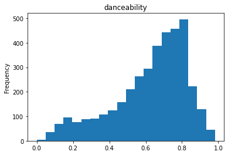

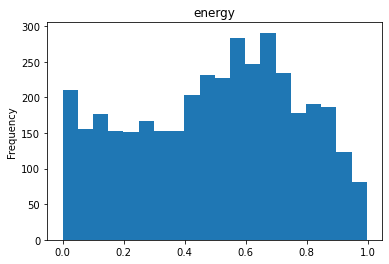

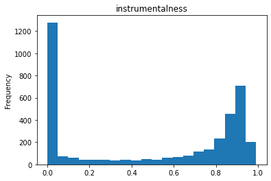

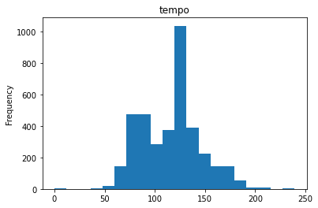

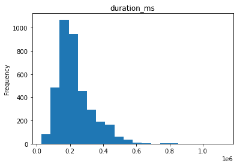

```python
for f in selected_features:
    features_full[f].plot.hist(bins=20)
    plt.title(f)
    plt.show()
```

We now are interested in mapping the correct track features to each row of our `history` dataframe. This is done using the `merge()` method in pandas.

```python
history_full = history.merge(features_full, how='left',
                             left_on='id', right_on='id')
```

```python
history.head(3)
```

|  | played_at | id | artist | name |
| --- | --- | --- | --- | --- |
| 0 | 2020-03-19T14:59:51.544Z | 6r647IcY3VbHY7zEmtAAdS | Ratatat | Bob Gandhi |
| 1 | 2020-03-19T15:02:35.733Z | 4CKJlhPFfD4NphIHayTngd | SLIGHT | DREAMIN |
| 2 | 2020-03-19T15:07:16.071Z | 2CQWQkDK3fLiaxXvrMclMA | The Avalanches | Frontier Psychiatrist |

```python
history_full.head()
```

|  | played_at | id | artist | name | danceability | energy | key | loudness | mode | speechiness | ... | instrumentalness | liveness | valence | tempo | type | uri | track_href | analysis_url | duration_ms | time_signature |
| --- | --- | --- | --- | --- | --- | --- | --- | --- | --- | --- | --- | --- | --- | --- | --- | --- | --- | --- | --- | --- | --- |
| 0 | 2020-03-19T14:59:51.544Z | 6r647IcY3VbHY7zEmtAAdS | Ratatat | Bob Gandhi | 0.663 | 0.582 | 10 | -8.426 | 0 | 0.043 | ... | 0.838000 | 0.3010 | 0.0984 | 135.320 | audio_features | spotify:track:6r647IcY3VbHY7zEmtAAdS | https://api.spotify.com/v1/tracks/6r647IcY3VbH... | https://api.spotify.com/v1/audio-analysis/6r64... | 240627 | 4 |
| 1 | 2020-03-19T15:02:35.733Z | 4CKJlhPFfD4NphIHayTngd | SLIGHT | DREAMIN | 0.718 | 0.816 | 7 | -4.771 | 1 | 0.403 | ... | 0.001810 | 0.0919 | 0.1100 | 92.714 | audio_features | spotify:track:4CKJlhPFfD4NphIHayTngd | https://api.spotify.com/v1/tracks/4CKJlhPFfD4N... | https://api.spotify.com/v1/audio-analysis/4CKJ... | 171754 | 4 |
| 2 | 2020-03-19T15:07:16.071Z | 2CQWQkDK3fLiaxXvrMclMA | The Avalanches | Frontier Psychiatrist | 0.700 | 0.901 | 6 | -7.440 | 1 | 0.264 | ... | 0.000092 | 0.3880 | 0.4220 | 98.889 | audio_features | spotify:track:2CQWQkDK3fLiaxXvrMclMA | https://api.spotify.com/v1/tracks/2CQWQkDK3fLi... | https://api.spotify.com/v1/audio-analysis/2CQW... | 288240 | 4 |
| 3 | 2020-03-19T15:10:38.374Z | 3ZbvZvQXAdc2YlLfJlNR0C | Admiral P | Gjï¿½r sï¿½ godt du kan | 0.661 | 0.842 | 8 | -3.814 | 1 | 0.266 | ... | 0.000000 | 0.4340 | 0.9470 | 165.808 | audio_features | spotify:track:3ZbvZvQXAdc2YlLfJlNR0C | https://api.spotify.com/v1/tracks/3ZbvZvQXAdc2... | https://api.spotify.com/v1/audio-analysis/3Zbv... | 210427 | 4 |
| 4 | 2020-03-19T15:13:38.896Z | 39qc0OEY3CQWfTQzeghYaY | Admiral P | Nydelig | 0.785 | 0.641 | 0 | -5.738 | 0 | 0.180 | ... | 0.000000 | 0.0573 | 0.6870 | 100.028 | audio_features | spotify:track:39qc0OEY3CQWfTQzeghYaY | https://api.spotify.com/v1/tracks/39qc0OEY3CQW... | https://api.spotify.com/v1/audio-analysis/39qc... | 188210 | 4 |

5 rows × 21 columns

Cool, let's see how the means of our selected features are distributed between hours of the day.

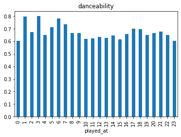

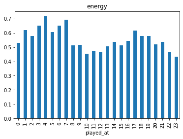

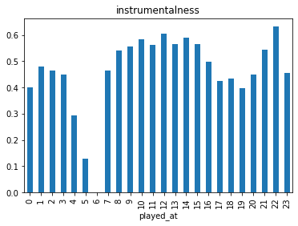

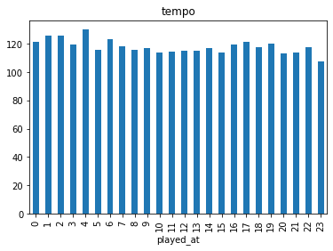

```python
for f in selected_features[:-1]:
    history_full.groupby(played_at.dt.hour)[f].mean().plot.bar()
    plt.title(f)
    plt.show()
```

Great, now all of our data including history and feature information are combined into one data frame. We are finally ready to build a machine learning model to predict what time of day a particular song most likely will be listened to. (Important to remember: we saw the largest song count for 16:00, meaning our model might choose this time slot very often.)

Here, the hour of day will be our target, `y`, and our selected features our attributes, `X`.

```python
y = played_at.dt.hour
X = history_full[selected_features]
```

```python
y.shape, X.shape
```

```
((7573,), (7573, 5))
```

We'll also need to read in the tools we'll need from `sklearn`.

```python
from sklearn.model_selection import train_test_split
from sklearn.tree import DecisionTreeClassifier, plot_tree
from sklearn.linear_model import LogisticRegression
from sklearn.linear_model import LinearRegression
from sklearn.naive_bayes import MultinomialNB
from sklearn.naive_bayes import BernoulliNB
```

We'll start by splitting our data.

```python
Xtr, Xte, ytr, yte = train_test_split(X, y)
```

Let's start by building a simple decision tree classifier.

```python
model_tree = DecisionTreeClassifier(max_depth=20)
model_tree.fit(Xtr, ytr)
None
```

We can measure how accurate our model is by comparing the predicted values of our test data `Xte` with their real values `yte`. We'll use an L1 error type, meaning we measure the error linearly.

```python
1./24
```

```
0.041666666666666664
```

```python
import numpy as np
sum(abs(yte == np.random.randint(0,24,len(yte))))/len(yte)
```

```
0.04012671594508976
```

```python
sum(abs(yte == model_tree.predict(Xte)))/len(yte)
```

```
0.09239704329461457
```

```python
sum(abs(yte - model_tree.predict(Xte)))/len(yte)
```

```
4.24181626187962
```

So our tree of depth 20 is on average about 4 hours off when estimating our listening time. We can see if it's possible to lower this error by pruning the tree.

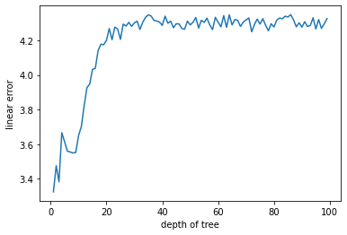

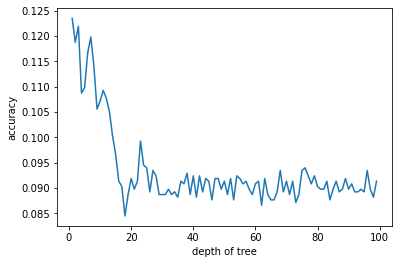

```python
error_tree = []
accuracy_tree = []
N = 100
for d in tqdm(range(1,N)):
    model_tree = DecisionTreeClassifier(max_depth=d)
    model_tree.fit(Xtr, ytr)
    error_tree.append(sum(abs(yte - model_tree.predict(Xte)))/len(yte))
    accuracy_tree.append(sum(abs(yte == model_tree.predict(Xte)))/len(yte))

# plot accuracy of different depths
plt.plot(range(1,N), error_tree)
plt.xlabel('depth of tree')
plt.ylabel('linear error')
plt.show()

# plot accuracy of different depths
plt.plot(range(1,N), accuracy_tree)
plt.xlabel('depth of tree')
plt.ylabel('accuracy')
plt.show()
```

```python
# accuracy_tree
```

We were able to get a smaller window of error, although it's still not great that our model is 3 hours off. As we can see, after a depth of around 6-7, increasing our `N` gives only higher errors. So maybe decision trees won't be the best at predicting on these data. Let's try a logistic regression instead.

```python
model_logr = LogisticRegression()
model_logr.fit(Xtr, ytr)
sum(abs(yte - model_logr.predict(Xte)))/len(yte)
```

```
3.2729672650475186
```

```python
sum(abs(yte == model_logr.predict(Xte)))/len(yte)
```

```
0.11404435058078141
```

```python
min(error_tree)
```

```
3.3252375923970434
```

```python
sum(abs(yte == model_logr.predict(Xte)))/len(yte)
```

```
0.11404435058078141
```

So out of the bag, logistic regression is slightly better than our tree model. We can try tuning logistic regression to see if we get a better fit on our data. We do this by changing the C parameter.

```python
error_logr = []
Cs = [0.0001, 0.001, 0.01, 0.1, 1., 10., 100.]
for c in Cs:
    model_logr = LogisticRegression(C=c)
    model_logr.fit(Xtr, ytr)
    error_logr.append(sum(abs(yte - model_logr.predict(Xte)))/len(yte))
```

```python
# plt.semilogx(Cs, accuracy_logr)
accuracy_logr
```

[output not shown]

```python
model_linr = LinearRegression()
model_linr.fit(Xtr, ytr)
sum(abs(yte - model_linr.predict(Xte)))/len(yte)
```

```
3.17102261277932
```

```python
sum(abs(yte == model_linr.predict(Xte)))/len(yte)
```

```
0.0
```

Linear model gave the best results we've seen so far, although not great accuracy from a statistics perspective.

## Conclusion of our models

All the model types we looked at here gave pretty estimates, resulting in high average errors. From this, we can conclude that building a model to correctly a type of song to play during a specific hour of the day is pretty difficult. This is because listening history is a noisy variable, with a number of external influences that are not included in these data.

On average, our models will be roughly 3 hours wrong. However, we saw a doubling of accuracy from a random model, so we do have a good start. For more precise models, I'll have to either add more data, or try different model types. Multilevel models, where different dimensions can be mapped according to different distributions could also be a next step here. The steps will have to be implemented in a later project.

Until then, have fun playing around with this API and maybe tweaking these models. I hope you learned something! :)